# Tumor purity exploration

SJ Spielman for CCDL

2023

This notebook performs the following:

- Explores the distribution of tumor purity values as well as their relationship to other metadata values
- Identifies RNA-level samples for which we reliably know their tumor purity based on associated WGS data
- Explores potential tumor purity thresholds that could be applied in other contexts to assess the influence of tumor purity on certain RNA-level analyses

## Functions

This section defines a function which is needed in this (and only in this!) notebook.

```r
# Function to make violin plots of tumor_fraction for either
# broad_histology_display or cancer_group_display groups
plot_tumor_violins <- function(df, display_name, display_hex, x_lab) {
  # Wrap group names to fit in the plot.
  # Then, filter to display_name group so that we can order by group-wise median,
  #  while ensuring that 'Other' is still last
  df <- df %>%
  mutate(display_var = stringr::str_wrap({{display_name}}, 25),
         display_var = forcats::fct_reorder(display_var, tumor_fraction),
         display_var = forcats::fct_relevel(display_var, "Other", after = Inf))

  # Plot
  ggplot(df) +
    aes(x = display_var,
        y = tumor_fraction,
        fill = {{display_hex}}) +
    geom_violin(alpha = 0.5) +
    stat_summary(geom = "point", fun.y = "median",
                 size = 0.75) +
    scale_fill_identity() +
    labs(
      x = x_lab,
      y = "Tumor purity from WGS"
    ) +
    theme(
      axis.text.x = element_text(angle = 45, hjust = 1, size = 6),
      axis.text.y = element_text(size = 6),
      axis.title = element_text(size = 7),
      axis.line = element_line(size = 0.25),
      axis.ticks = element_line(size = 0.25)
    )
}
```

## Set directories and files

```r
# Input
root_dir <- rprojroot::find_root(rprojroot::has_dir(".git"))
data_dir <- file.path(root_dir, "data")
pal_dir <- file.path(root_dir, "figures", "palettes")
metadata_file <- file.path(data_dir, "pbta-histologies.tsv")
pal_file <- file.path(pal_dir, "broad_histology_cancer_group_palette.tsv")

# Output directories
results_dir <- file.path("results")
if (!(dir.exists(results_dir))) {
  dir.create(results_dir)
}
plots_dir <- file.path("plots")
if (!(dir.exists(plots_dir))) {
  dir.create(plots_dir)
}
rna_stranded_df_file <- file.path(results_dir, "rna_stranded_same-extraction.tsv")
cancer_group_violin_file <- file.path(plots_dir, "cancer_group_tumor_fraction.pdf")

# CSV file for Zenodo upload
figS3a_csv <- file.path(results_dir, "figure-S3a-data.csv")
```

Read in:

```r
metadata <- read_tsv(metadata_file)
palette_mapping_df <- read_tsv(pal_file)
```

## Exploration of `tumor_fraction`

The quantity `tumor_fraction` provides information about what percent of the sample was likely tumor. We’ll explore this variable:

```r
# Note that this quantity is only recorded, if ever, with WGS libraries:
presence_table <- table(metadata$experimental_strategy,
                        is.na(metadata$tumor_fraction))
colnames(presence_table) <- c("Tumor fraction known", "Tumor fraction unknown")
presence_table
```

```
                      Tumor fraction known Tumor fraction unknown
  RNA-Seq                                0                   1035
  Targeted Sequencing                    0                      2
  WGS                                  928                    813
  WXS                                    0                     62
```

Tumor fraction was calculated for WGS samples:

```r
metadata_tumor_wgs <- metadata %>%
  filter(experimental_strategy == "WGS",
         sample_type == "Tumor")

# For what percentage of tumor samples is purity known? Nearly all of them!
sum(!is.na(metadata_tumor_wgs$tumor_fraction)) / nrow(metadata_tumor_wgs)
```

```
[1] 0.987234
```

Distribution of tumor purity:

```r
summary(metadata_tumor_wgs$tumor_fraction)
```

```
    Min.  1st Qu.   Median     Mean  3rd Qu.     Max.     NA's
0.000123 0.463044 0.756648 0.696020 1.000000 1.000000       12
```

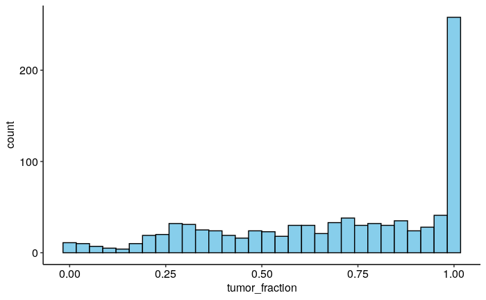

```r
ggplot(metadata_tumor_wgs) +
  aes(x = tumor_fraction) +
  geom_histogram(color = "black", fill = "skyblue")
```

Distribution by cancer group and broad histology, where the point in each plot is the median value (and groups are ordered by median).

```r
# combine metadata with palette:
tumor_palette_df <- metadata_tumor_wgs %>%
  inner_join(palette_mapping_df) %>%
  select(Kids_First_Biospecimen_ID,
         tumor_fraction,
         cancer_group_display,
         cancer_group_hex,
         broad_histology_display,
         broad_histology_order,
         broad_histology_hex) %>%
  drop_na()
# Cancer group
cancer_group_violins <- plot_tumor_violins(tumor_palette_df, cancer_group_display, cancer_group_hex, "Cancer group")

# Broad histology
broad_histology_violins <- plot_tumor_violins(tumor_palette_df, broad_histology_display, broad_histology_hex, "Broad histology")
```

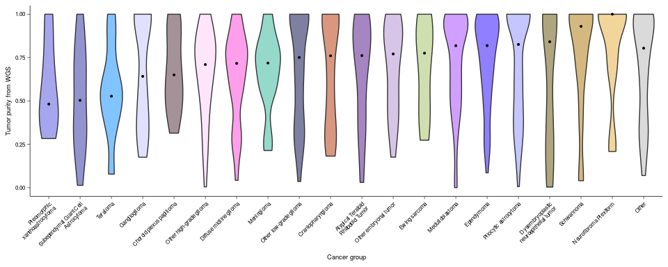

```r
# Print plots
cancer_group_violins
```

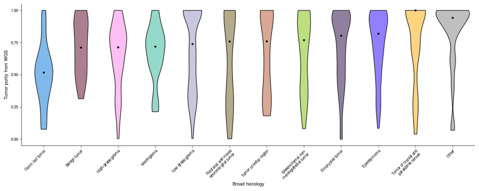

```r
broad_histology_violins
```

We’ll export the cancer group plot:

```r
ggsave(cancer_group_violin_file,
       cancer_group_violins,
       width = 6.75,
       height = 2.3,
       useDingbats = FALSE)
```

We’ll also export the data underlying this plot:

```r
tumor_palette_df %>%
  # clean up columns for export
  dplyr::select(Kids_First_Biospecimen_ID, tumor_fraction, cancer_group_display, cancer_group_hex) %>%
  dplyr::arrange(Kids_First_Biospecimen_ID) %>%
  readr::write_csv(figS3a_csv)
```

The following plot shows the distribution across sequencing centers, highlighting cancer groups:

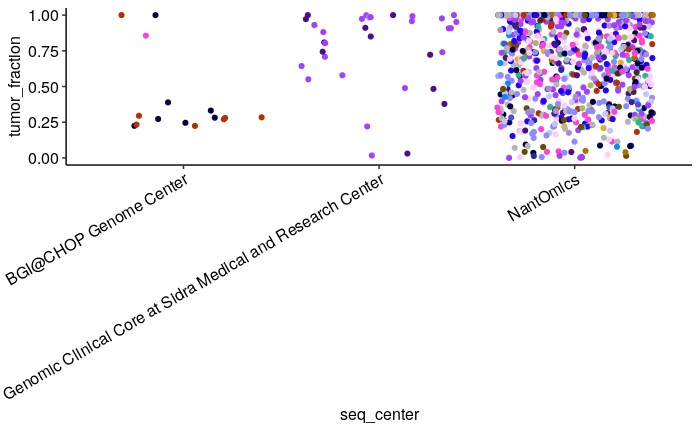

```r
# use jitter to highlight diagnoses
seq_center_df <- tumor_palette_df %>%
  inner_join(
    select(metadata,
           Kids_First_Biospecimen_ID,
           seq_center)
  )
ggplot(seq_center_df) +
  aes(x = seq_center,
      y = tumor_fraction,
      color = cancer_group_hex) +
  geom_jitter() +
  scale_color_identity() +
  theme(axis.text.x = element_text(angle = 30, hjust=1))
```

```r
# What are the cancer groups at the smaller centers?
seq_center_df %>%
  count(seq_center, cancer_group_display) %>%
  arrange(seq_center)
```

| seq_center | cancer_group_display | n |
| --- | --- | --- |
| BGI@CHOP Genome Center | Craniopharyngioma | 7 |
| BGI@CHOP Genome Center | Diffuse midline glioma | 1 |
| BGI@CHOP Genome Center | Other low-grade glioma | 7 |
| Genomic Clinical Core at Sidra Medical and Research Center | Atypical Teratoid Rhabdoid Tumor | 11 |
| Genomic Clinical Core at Sidra Medical and Research Center | Medulloblastoma | 21 |
| Genomic Clinical Core at Sidra Medical and Research Center | Other embryonal tumor | 1 |
| NantOmics | Atypical Teratoid Rhabdoid Tumor | 18 |
| NantOmics | Choroid plexus papilloma | 12 |
| NantOmics | Craniopharyngioma | 32 |
| NantOmics | Diffuse midline glioma | 68 |

[output cut: 16 more lines]

## Tumor fraction at the RNA level

Tumor fractions explored above were derived from WGS data. Estimating tumor fraction from RNA directly is challenging since methods focus on estimating proportion of immune cells and assuming the rest is tumor, which is not a fair assumption for many of these diagnoses.

Therefore, for RNA data tumor purity estimates, we should instead directly use tumor fraction values but *only for those samples where DNA and RNA sequencing were performed on the same extraction*. We cannot really know the RNA tumor purity for samples that have separate DNA/RNA extractions.

This extraction information is present in data release `>=v23` - we’re interested in “Same extraction” samples. First, how many such samples are there?

```r
table(metadata$extraction_type)
```

```
Different tissue aliquot          Same extraction      Same tissue aliquot
                      49                      912                       44
```

We’ll need to get the RNA equivalents (since these are all WGS), and we’ll map over this information using the `sample_id` information, as was done for the oncoprint module: https://github.com/AlexsLemonade/OpenPBTA-analysis/blob/5fe10b88aaa5176fa6577ffd6c8388be05098e83/analyses/oncoprint-landscape/01-map-to-sample_id.R

As part of this, we want to find the ambiguous `sample_id` samples so that we don’t include them, as described: https://github.com/AlexsLemonade/OpenPBTA-analysis/blob/5fe10b88aaa5176fa6577ffd6c8388be05098e83/analyses/oncoprint-landscape/01-map-to-sample_id.R#L153

> An ambiguous sample_id will have more than 2 rows associated with it in the histologies file when looking at tumor samples – that means we won’t be able to determine when an WGS/WXS assay maps to an RNA-seq assay

```r
# find the ambiguous samples to flag for removal
# here the composition does not matter, unlike in the linked oncoprint filtering
ambiguous_sample_ids <- metadata %>%
  filter(sample_type == "Tumor") %>%
  count(sample_id) %>%
  filter(n > 2) %>%
  pull(sample_id)
```

Now we can map over the tumor fractions to RNA-Seq samples.

```r
# Find the RNA samples of interest
same_extraction_stranded_metadata <- metadata %>%
  filter(experimental_strategy == "RNA-Seq",
         RNA_library == "stranded",
         extraction_type == "Same extraction") %>%
  # remove tumor_fraction since it will conflict after joining
  select(-tumor_fraction)

# We can use these ids to map back to their associated tumor fractions
rna_stranded_df <- metadata_tumor_wgs %>%
  # keep only sample_id's of interest: same extraction with a stranded RNA pair, and NOT ambiguous
  filter(sample_id %in% same_extraction_stranded_metadata$sample_id,
         !(sample_id %in% ambiguous_sample_ids)) %>%
  # find information to join in
  select(sample_id, tumor_fraction) %>%
  distinct() %>%
  # Join tumor fractions with RNA metadata
  right_join(same_extraction_stranded_metadata, by = "sample_id") %>%
  # Keep only columns of interest, to avoid conflicts with future joins
  select(contains("Kids_First"), sample_id, tumor_fraction,
         cancer_group, broad_histology) %>%
  # remove any unknowns
  drop_na(tumor_fraction)
```

The new `rna_stranded_df` contains information of interest for transcriptomic exploration: `tumor_fraction` values for stranded RNA-Seq samples that were from the same extraction as corresponding WGS for which the tumor purity was quantified.

```r
rna_stranded_df
```

| Kids_First_Biospecimen_ID | Kids_First_Participant_ID | sample_id | tumor_fraction | cancer_group | broad_histology |
| --- | --- | --- | --- | --- | --- |
| BS_014EVM2D | PT_S21ZTKPS | 7316-362 | 0.082628825 | Low-grade glioma astrocytoma | Low-grade astrocytic tumor |
| BS_03FT4S8B | PT_5KRVE8E4 | 7316-1671 | 0.796933600 | Craniopharyngioma | Tumors of sellar region |
| BS_0448A413 | PT_VHS5RM2K | 7316-364 | 0.804204187 | Ewing sarcoma | Mesenchymal non-meningothelial tumor |
| BS_044XZ8ST | PT_QAX38GM7 | 7316-3570 | 1.000000000 | Pilocytic astrocytoma | Low-grade astrocytic tumor |
| BS_052PZFMK | PT_N3205P0D | 7316-1099 | 0.905340493 | High-grade glioma astrocytoma | Diffuse astrocytic and oligodendroglial tumor |
| BS_063ERW0R | PT_3V5GTCJR | 7316-1646 | 1.000000000 | Pilocytic astrocytoma | Low-grade astrocytic tumor |
| BS_06AMMCXR | PT_Q3EP24V1 | 7316-154 | 0.277586306 | Low-grade glioma astrocytoma | Low-grade astrocytic tumor |
| BS_06XH7EVF | PT_G8DRDA33 | 7316-879 | 1.000000000 | NA | Benign tumor |
| BS_07ANYSYQ | PT_S4H6KA09 | 7316-2134 | 0.657334393 | Ependymoma | Ependymal tumor |
| BS_09R7GDA7 | PT_0PT33SCF | 7316-1100 | 0.420941726 | CNS Embryonal tumor | Embryonal tumor |

[output cut: 733 more lines]

Let’s export this TSV for future use:

```r
# keep only IDs and tumor_fraction for export
rna_stranded_df_export <- rna_stranded_df %>%
  select(Kids_First_Biospecimen_ID, sample_id, tumor_fraction)

write_tsv(rna_stranded_df_export,
          rna_stranded_df_file)
```

We might also like to see this distribution of values, since only these are relevant for RNA-level:

```r
summary(rna_stranded_df$tumor_fraction)
```

```
     Min.   1st Qu.    Median      Mean   3rd Qu.      Max.
0.0001232 0.4589042 0.7604890 0.7018232 1.0000000 1.0000000
```

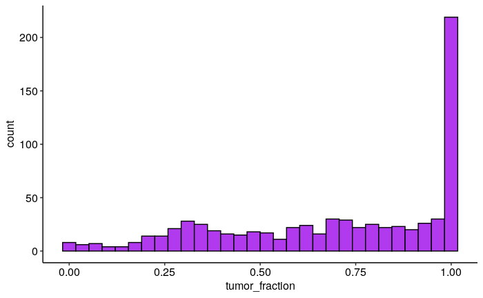

```r
ggplot(rna_stranded_df) +
  aes(x = tumor_fraction) +
  geom_histogram(color = "black", fill = "darkorchid2")
```